# Distributions and Random Numbers

Feng Li

School of Statistics and Mathematics

Central University of Finance and Economics

feng.li@cufe.edu.cn

https://feng.li/statcomp

## Basic concepts of random numbers

### Preliminary

- **Pseudo random numbers**
  - an algorithm for generating a sequence of numbers that approximates the properties of random numbers.
  - The sequence is not truly random in that it is completely determined by a relatively small set of initial values, called the PRNG’s state.
  - Pseudo random numbers are important in practice for their **speed** in number generation and their **reproducibility**.
- **Random seed**

  A random seed (or seed state, or just seed) is a number (or vector) used to initialize a pseudo random number generator.
- The most important random numbers are from uniform distributed numbers.

  `> runif(n,a,b)`
- Numbers selected from a non-uniform probability distribution can be generated using a uniform distribution PRNG and a function that relates the two distributions.
- Assume you have uniformly distributed random numbers from [0, 1], how do you extend it to [a, b]?

## Continuous random variables

### Normal Distribution

- **The normal density function** $$f(x, \mu, \sigma) = \frac{1}{\sigma\sqrt{2\pi}} e^{-\frac{(x-\mu)^2}{2\sigma^2} }$$

  `> dnorm(x,mu,sigma)`

  `> dnorm(x,mu,sigma, log=TRUE)`
  - In theory, `dnorm(x,mu,sigma, log=TRUE)==log(dnorm(x,mu,sigma))`
  - but `dnorm(x,mu,sigma, log=TRUE)` but is more stable for very large values. Why?
  - **We love logs**.

```r
dnorm(100, mean=0, sd=1)
log(dnorm(100, mean=0, sd=1))

dnorm(100, mean=0, sd=1, log=TRUE)
```

0

-Inf

-5000.9189385332

- **The CDF** (Cumulative Distribution Function) $$\Phi(x)\;=\int_{-\infty}^x f(t, \mu, \sigma) d t$$

  `> pnorm(q,mu,sigma)`
- **The quantile** (Given CDF, what is x?), i.e. $\Phi^{-1}(p)$

  `> qnorm(p,mu,sigma)`
- **Random numbers from normal distribution**

  `> rnorm(n,mu,sigma)`

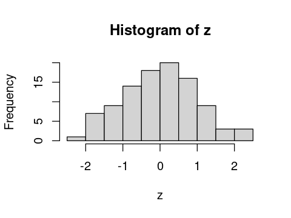

```r
z = rnorm (100,mean=0, sd=1)
hist(z)
```

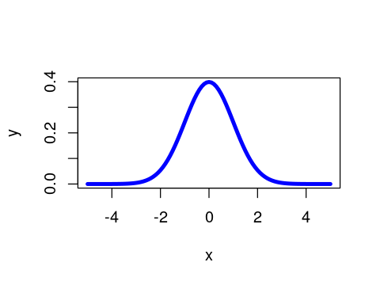

```r
x  = seq(-5, 5, 0.1)
y = dnorm(x = x, mean = 0, sd = 1)
plot(x, y, col = "blue", type = "l", lwd = 4)
```

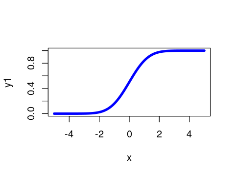

```r
y1 = pnorm(q = x, mean = 0, sd = 1)
plot(x, y1, col = "blue", type = "l", lwd = 4)
```

### Other types of continuous distribution

- Distribution Function in R

  Student t: `{p,d,q}t`

  Chi squared: `{p,d,q}chi`

  Gamma: `{p,d,q}gamma`

  Exponential `{p,d,q}exp`
- For a significance test, what distribution do you use?

# Discrete random variables

### Discrete random variables

- Distribution Function in R

  Binomial: `{p,d,q}binorm`

  Negative binomial: `{p,d,q}nbinom`

  Poisson: `{p,d,q}pois`

  Geometric: `{p,d,q}geom`
- Bernoulli distribution is a special case of binomial distribution.

### Suggested reading

- Jones (2009): **Chapter 14, 15, 16**